# How Runoff Rules Pick House Nominees, 2004–2022

The rule that picks the nominee, found without reading a single statute

Democracy’s Data

Last updated September 13, 2026 at 10:53a EDT

In March 2014, Ralph Hall came first in the Republican primary — the election in which the party’s voters choose its nominee — for Texas’s fourth district. He had represented it for 34 years and was the oldest person ever to serve in the House.[^1] He took 45.4 percent, and the man in second, John Ratcliffe, took 28.8.

Two months later he was not the nominee. Texas requires a majority — more than half of all the votes cast — so the top two went to a runoff, a second election between the two of them alone, and Ratcliffe won it.[^2] **Nothing about the votes changed. The rule finished the count differently.** Had Hall’s district been in Pennsylvania, where a plurality — simply the most votes, however far short of half — wins, he would have been renominated on the night.[^3]

A nomination is usually described as a measurement of what a party’s voters want. This brief asks how much of the answer is instead the rule that finishes the count. Where does that rule live, how often does it change the outcome, and how much of it can you work out without opening a statute book?

## The test

The data is the Federal Election Commission’s *Federal Elections* series, the compilation the Commission publishes after every two-year election, for 2004 through 2022, downloadable from the [Commission](https://www.fec.gov/introduction-campaign-finance/election-results-and-voting-information/). For every federal candidate it reports the primary vote, the runoff vote and the general-election vote, assembled from the official counts of the state election officials. The ten workbooks are kept with the `retirements` brief.

This source fits the question because it is the only federal record that reports both rounds. Each state writes its own nominating rule into its own election code, and there is no federal table of the rules. What the Commission records is narrower and more useful: when a runoff happened, it reports the runoff votes. That turns out to be enough to recover the rule from its outcomes. This brief belongs to the cluster the roster chapter introduces — records about who ends up holding office, read here for the step where a party settles on one name.

The test: for every state, squeeze the threshold from both sides of its outcomes, and then count how often the second round reverses the first.

## The data

The ten workbooks hold 22,066 House candidate rows, of which 16,547 of 22,066 are on a Democratic or Republican line. The Commission has changed its layout between editions — sheet names, column headings, and party labels that are one letter in some years (`D`, `R`) and three in others (`DEM`, `REP`) — and a reader who takes only one form of the party label loses two entire elections without a warning.

| Quantity | Value |
| --- | --- |
| Elections covered | 10 |
| Years | 2004 to 2022 |
| House candidate rows | 22,066 |
| Of those, on a major-party line | 16,547 of 22,066 |
| Contested primaries with usable vote totals | 3,705 |
| Of those, in all-party states, set aside | 576 |
| Runoffs | 173 |

The rows are grouped into **contested primaries**: one state, one district, one party, one cycle, with at least two candidates who received a vote total. That is the nomination that was actually at stake. The 576 contests in California and Washington pool both parties onto one ballot — a **top-two** primary, from which the two leaders advance whatever their party — so a share there is not comparable to a party primary’s, and they are set aside. Louisiana is dropped because in most of these years it holds no party primary at all.

Four tables come out. `contests.csv` is one row per contested primary, with `leader_share` and a `runoff` flag. `runoffs.csv` keeps the 173 contests that went to a second round, with `leader_share` and `leader_won_runoff`. `brackets.csv` gives each runoff state the highest leader share that still produced a runoff, the lowest that did not, and the `bracket_width` between them. `by_year.csv` counts contests, runoffs and overturns by cycle.

> **Before you read on, write a number down.** Across 2004 to 2022 there were 173 House primary runoffs. In each, the candidate who came first in the primary faced the candidate who came second. **How many times did the person who came second go on to win?** Commit to a count out of 173 before you look at the figures.

## What it says about democracy

A runoff happens when the leading candidate falls short of some threshold. You do not know the threshold. But you can see, for every contest, what the leader took and whether a runoff followed.

**So the outcomes squeeze the rule from both sides.** The highest leader share that still went to a runoff must sit *below* the threshold. The lowest share that did not must sit *above* it. The rule is somewhere in between.

Georgia shows the squeeze. Across 105 contested primaries it held 27 runoffs. The highest share a leader took and still had to face a second round was 49.5 percent, so the threshold is above that. The lowest share that settled a nomination outright was 50.2 percent, so the threshold is below that. Georgia’s rule lives in a window 0.7 of a point wide, and 50 percent — a majority — sits inside it.

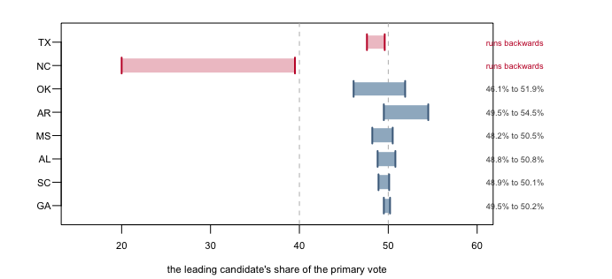

**Figure 1. Where each state’s runoff threshold has to be.** One bar per state that held a House runoff, because the finding is an interval, not a trend. The left edge of each bar is the highest leader share that still produced a runoff, the right edge the lowest share that did not; for a fixed rule, the threshold lies inside the bar.

6 of the 8 states bracket cleanly, and every one of them brackets half the vote. The tightest is GA, 49.5 to 50.2 percent, which pins the rule to within 0.7 of a percentage point. Nobody looked up a statute to get that.

Two states break the method, and they are the exceptions with a story.

| State | Runoffs | Contests | Highest share that still went to a runoff | Lowest share that did not |
| --- | --- | --- | --- | --- |
| TX | 80 | 306 | 49.6 | 47.6 |
| NC | 11 | 149 | 39.5 | 20.0 |

**A bracket cannot run backwards if the rule is fixed.** A North Carolina contest at 39.5 percent went to a runoff, and one at 20.0 percent did not. No single threshold does both. So the rule was not fixed. Split North Carolina by cycle and it appears:

| Cycle | Contests under 40% | Of those, went to a runoff | Highest share that still went to a runoff | Lowest share that did not |
| --- | --- | --- | --- | --- |
| 2004 | 2 | 2 | 35.0 | 45.4 |
| 2010 | 3 | 3 | 39.5 | 40.2 |
| 2012 | 3 | 3 | 37.8 | 43.5 |
| 2014 | 2 | 2 | 34.3 | 40.9 |
| 2016 | 3 | 0 | NA | 20.0 |
| 2020 | 1 | 1 | 22.7 | 46.3 |
| 2022 | 5 | 0 | NA | 31.2 |

In 2010 the bracket closes at 40 percent, pinned to within 0.7 of a point by two contests in one year. In 2016 three contests fell under 40 percent, the lowest at 20.0 percent, and none triggered a second round — for that cycle there was effectively no threshold. Then it closes again, lower: a 2020 contest at 22.7 percent went to a runoff, and by 2022 the rule sits somewhere around 30.[^4] **The threshold moved twice, and both moves are visible in nothing but outcomes.** Texas fails for a smaller reason: its bracket runs backwards by 2.0 points because a second-place finisher just under half can decline the runoff rather than contest it.

How often does the second round matter? The record answers directly, because it reports both rounds.

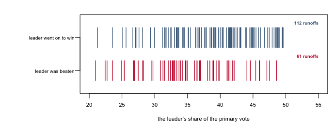

**Figure 2. Every House primary runoff from 2004 to 2022, one tick per contest.** Each tick sits at the share the primary leader took; the upper row is runoffs the leader went on to win, the lower row runoffs the leader lost.

**61 of 173.** The candidate who came second in the primary went on to win the nomination in more than a third of these contests. Most readers guess a handful, because coming first sounds like an advantage that carries. It carries, and it is not decisive. The runoff is not a formality that ratifies the first round. It is a second election, and it frequently disagrees with the first.

Most states, though, hold no runoff at all: a plurality wins, however small.

| The winner took | Primaries |
| --- | --- |
| under half the vote | 593 of 2,956 (20.1%) |
| under 40 percent | 279 of 2,956 (9.4%) |
| under 35 percent | 157 of 2,956 (5.3%) |

**593 nominations were settled outright by a candidate most primary voters voted against.** Every one of those would have gone to a runoff in Georgia or Alabama. What would have happened there is unknowable, but Figure 2 gives the only relevant guide: when contests like these do go to a second round, the first-round leader loses about a third of the time. The same distribution of votes yields one nominee under one state’s rule and, often, a different nominee under another’s. And the rule sits in fifty separate election codes, appears in no federal table, and changes when a legislature feels like changing it.

## What this brief cannot tell you

**It cannot tell you who would have won a runoff that never happened.** That is the central question and it is unanswerable. A runoff is a different election with a different electorate, and the 61 overturns in Figure 2 are the nearest thing to an answer, not the answer.

**It cannot give you the rules themselves.** Figure 1 brackets a threshold; it does not read a statute. Where a state held no runoff in twenty years, this file says nothing about its rule, including whether it has one. And a bracket is only as tight as the contests that happened. Georgia’s is narrow because Georgia ran 27 runoffs across 105 contests; a state with two runoffs gets a wide bracket and no more knowledge than that.

**Turnout is missing, and it is not a detail.** These are shares of whoever voted, and a runoff electorate is usually smaller than a primary’s. Two rounds can disagree because voters changed their minds or because different people showed up, and nothing here separates those.

**And a rule is not only a threshold.** Who may vote, when the primary is held, how a candidate qualifies, and whether the second-place finisher must request the runoff all vary by state. None of that is in this file.

## What you should have learned

- A nomination is a measurement plus a rule for finishing it, and the rule does real work: 61 of 173 House primary runoffs from 2004 to 2022 reversed the first round.
- A state’s runoff threshold can be recovered from outcomes alone: 6 of 8 runoff states bracket cleanly around half the vote, the tightest to within 0.7 of a point.
- A bracket that will not close is a finding too: North Carolina’s threshold moved twice inside these ten elections, visibly, without the file ever stating a rule.
- In plurality states, 593 nominations were settled outright by a winner who took under half the vote — contests a majority-rule state would have sent to a second round.
- The counting rule lives in fifty separate state codes and no federal table, which is why the practical way to find it was to look at what happened.

## Extensions

None of these is answered above, and every one can be answered from the tables the Sources section hands over.

- `brackets.csv` finds each state’s threshold by bracketing it. Sort by `bracket_width`. Which states can you pin down exactly, and which are still ambiguous?
- `by_year.csv` counts contests and `overturned` runoffs by cycle. Work out how often the rule changes the answer, year by year. Is the overturn rate steady?
- `runoffs.csv` has `leader_share` and `leader_won_runoff`. Find the leaders who lost. How far ahead were they after the first round?
- `nonclosing_by_year.csv` holds the state-years where the bracket does not close. Read North Carolina’s rows. At what cycle does the change become visible?

Two stretch ideas point past the spreadsheet. Look up one runoff state’s actual statute, Georgia’s or Texas’s, and check it against the bracket Figure 1 found. Then find the North Carolina session law that moved its threshold, and date it against the cycles above. And the same workbooks carry Senate races: rebuild the brackets from Senate contests and see whether they agree with the House ones.

## Sources

**Data**

- Federal Election Commission, *Federal Elections*, the biennial compilations for 2004 through 2022. https://www.fec.gov/introduction-campaign-finance/election-results-and-voting-information/ — 22,066 House candidate rows across 10 elections. **The primary and runoff vote totals are the Commission’s, compiled from the official canvasses of the state election officials.** The ten workbooks are kept with the `retirements` brief. The validation results are reproduced in `checks.csv`.

**The data itself**

Every figure above is drawn from these tables. They are plain CSV, they open in a spreadsheet, and they are yours to take further.

`brackets.csv`, `by_year.csv`, `contests.csv`, `nonclosing_by_year.csv`, `runoffs.csv`

One more file is not data about the subject – it is how this chapter checked its own work: `checks.csv`, the arithmetic verified before anything was drawn.

[^1]: Office of the Historian, U.S. House of Representatives, “Hall, Ralph Moody,” https://history.house.gov/People/Listing/H/HALL,-Ralph-Moody-(H000067)/; KERA News, “Ralph Hall, Oldest-Ever Member of U.S. House, Dead at Age 95,” 7 March 2019, https://www.keranews.org/politics/2019-03-07/ralph-hall-oldest-ever-member-of-u-s-house-dead-at-age-95.
[^2]: Tex. Elec. Code § 172.003, “Majority Vote Required,” https://statutes.capitol.texas.gov/Docs/EL/htm/EL.172.htm.
[^3]: Which states send primaries to a runoff, and at what threshold, is tabulated by the National Conference of State Legislatures, “Primary Runoffs,” https://www.ncsl.org/elections-and-campaigns/primary-runoffs; Pennsylvania is not among them.
[^4]: The statute as it now reads sets the line at 30 percent: N.C. Gen. Stat. § 163-111, https://www.ncleg.gov/EnactedLegislation/Statutes/HTML/BySection/Chapter_163/GS_163-111.html. When it moved, and from where, is the stretch exercise at the end.